# Hotel bookings

Uzma Anjum

2024-05-23

## Setting up environment

Initially I need to set up my R environment by installing and loading required packages such as ‘tidyverse’,‘skimr’,‘janitor’,‘dplyr’ and ’ggplot2’packages.

```r
install.packages("tidyverse")
library(tidyverse)
```

## Import dataset with a new dataframe

```r
bookings_df <- read_csv("hotel_bookings.csv")
```

## Get an overview of data

```r
glimpse(bookings_df)
```

```
## Rows: 119,390
## Columns: 32
## $ hotel                          <chr> "Resort Hotel", "Resort Hotel", "Resort…
## $ is_canceled                    <dbl> 0, 0, 0, 0, 0, 0, 0, 0, 1, 1, 1, 0, 0, …
## $ lead_time                      <dbl> 342, 737, 7, 13, 14, 14, 0, 9, 85, 75, …
## $ arrival_date_year              <dbl> 2015, 2015, 2015, 2015, 2015, 2015, 201…
## $ arrival_date_month             <chr> "July", "July", "July", "July", "July",…
## $ arrival_date_week_number       <dbl> 27, 27, 27, 27, 27, 27, 27, 27, 27, 27,…
## $ arrival_date_day_of_month      <dbl> 1, 1, 1, 1, 1, 1, 1, 1, 1, 1, 1, 1, 1, …
## $ stays_in_weekend_nights        <dbl> 0, 0, 0, 0, 0, 0, 0, 0, 0, 0, 0, 0, 0, …
## $ stays_in_week_nights           <dbl> 0, 0, 1, 1, 2, 2, 2, 2, 3, 3, 4, 4, 4, …
## $ adults                         <dbl> 2, 2, 1, 1, 2, 2, 2, 2, 2, 2, 2, 2, 2, …
## $ children                       <dbl> 0, 0, 0, 0, 0, 0, 0, 0, 0, 0, 0, 0, 0, …
## $ babies                         <dbl> 0, 0, 0, 0, 0, 0, 0, 0, 0, 0, 0, 0, 0, …
## $ meal                           <chr> "BB", "BB", "BB", "BB", "BB", "BB", "BB…
```

[output cut: 19 more lines]

```r
colnames(bookings_df)
```

```
##  [1] "hotel"                          "is_canceled"
##  [3] "lead_time"                      "arrival_date_year"
##  [5] "arrival_date_month"             "arrival_date_week_number"
##  [7] "arrival_date_day_of_month"      "stays_in_weekend_nights"
##  [9] "stays_in_week_nights"           "adults"
## [11] "children"                       "babies"
## [13] "meal"                           "country"
## [15] "market_segment"                 "distribution_channel"
## [17] "is_repeated_guest"              "previous_cancellations"
## [19] "previous_bookings_not_canceled" "reserved_room_type"
## [21] "assigned_room_type"             "booking_changes"
## [23] "deposit_type"                   "agent"
## [25] "company"                        "days_in_waiting_list"
## [27] "customer_type"                  "adr"
## [29] "required_car_parking_spaces"    "total_of_special_requests"
## [31] "reservation_status"             "reservation_status_date"
```

## Manipulate data

Here I am arranging data in ascending and descending orders on specific columns to focus on bookings that were made in advance

```r
arrange(bookings_df, lead_time)
```

```
## # A tibble: 119,390 × 32
##    hotel        is_canceled lead_time arrival_date_year arrival_date_month
##    <chr>              <dbl>     <dbl>             <dbl> <chr>
##  1 Resort Hotel           0         0              2015 July
##  2 Resort Hotel           0         0              2015 July
##  3 Resort Hotel           0         0              2015 July
##  4 Resort Hotel           0         0              2015 July
##  5 Resort Hotel           0         0              2015 July
##  6 Resort Hotel           0         0              2015 July
##  7 Resort Hotel           0         0              2015 July
##  8 Resort Hotel           0         0              2015 July
##  9 Resort Hotel           0         0              2015 July
## 10 Resort Hotel           0         0              2015 July
## # ℹ 119,380 more rows
## # ℹ 27 more variables: arrival_date_week_number <dbl>,
## #   arrival_date_day_of_month <dbl>, stays_in_weekend_nights <dbl>,
## #   stays_in_week_nights <dbl>, adults <dbl>, children <dbl>, babies <dbl>,
## #   meal <chr>, country <chr>, market_segment <chr>,
## #   distribution_channel <chr>, is_repeated_guest <dbl>,
## #   previous_cancellations <dbl>, previous_bookings_not_canceled <dbl>, …
```

```r
arrange(bookings_df, desc(lead_time))
```

```
## # A tibble: 119,390 × 32
##    hotel        is_canceled lead_time arrival_date_year arrival_date_month
##    <chr>              <dbl>     <dbl>             <dbl> <chr>
##  1 Resort Hotel           0       737              2015 July
##  2 Resort Hotel           0       709              2016 February
##  3 City Hotel             1       629              2017 March
##  4 City Hotel             1       629              2017 March
##  5 City Hotel             1       629              2017 March
##  6 City Hotel             1       629              2017 March
##  7 City Hotel             1       629              2017 March
##  8 City Hotel             1       629              2017 March
##  9 City Hotel             1       629              2017 March
## 10 City Hotel             1       629              2017 March
## # ℹ 119,380 more rows
## # ℹ 27 more variables: arrival_date_week_number <dbl>,
## #   arrival_date_day_of_month <dbl>, stays_in_weekend_nights <dbl>,
## #   stays_in_week_nights <dbl>, adults <dbl>, children <dbl>, babies <dbl>,
## #   meal <chr>, country <chr>, market_segment <chr>,
## #   distribution_channel <chr>, is_repeated_guest <dbl>,
## #   previous_cancellations <dbl>, previous_bookings_not_canceled <dbl>, …
```

## New dataframe bookings_df_v2

And then i created a new dataframe to save the changes made by arrange function

```r
bookings_df_v2 <- arrange(bookings_df, desc(lead_time))
```

## Find out max and min values

finding out the maximum and minimum lead times without sorting the whole dataset using the `arrange()` function. Try it out using the max() and min() functions below:

```r
max(bookings_df$lead_time)
```

```
## [1] 737
```

```r
min(bookings_df$lead_time)
```

```
## [1] 0
```

```r
mean(bookings_df$lead_time)
```

```
## [1] 104.0114
```

## Filter data

First step will be creating a new data set that only contains data about city hotels.It is done by using the `filter()` function, and name new data frame ‘bookings_city’:

```r
bookings_city <-  filter(bookings_df, bookings_df$hotel=="City Hotel")
```

```r
head(bookings_city)
```

```
## # A tibble: 6 × 32
##   hotel      is_canceled lead_time arrival_date_year arrival_date_month
##   <chr>            <dbl>     <dbl>             <dbl> <chr>
## 1 City Hotel           0         6              2015 July
## 2 City Hotel           1        88              2015 July
## 3 City Hotel           1        65              2015 July
## 4 City Hotel           1        92              2015 July
## 5 City Hotel           1       100              2015 July
## 6 City Hotel           1        79              2015 July
## # ℹ 27 more variables: arrival_date_week_number <dbl>,
## #   arrival_date_day_of_month <dbl>, stays_in_weekend_nights <dbl>,
## #   stays_in_week_nights <dbl>, adults <dbl>, children <dbl>, babies <dbl>,
## #   meal <chr>, country <chr>, market_segment <chr>,
## #   distribution_channel <chr>, is_repeated_guest <dbl>,
## #   previous_cancellations <dbl>, previous_bookings_not_canceled <dbl>,
## #   reserved_room_type <chr>, assigned_room_type <chr>, …
```

### Check what the average lead time for this set of hotels is, just like for all of hotels before:

```r
mean(bookings_city$lead_time)
```

```
## [1] 109.7357
```

### Using ‘groupby()’ and ‘summarize()’

```r
bookings_summary <- bookings_df %>%
                    group_by(hotel) %>%
                    summarise(average_lead_time=mean(lead_time),
                    min_lead_time=min(lead_time),
                    max_lead_time=max(lead_time))
```

Now check it out using head() function.

```r
head(bookings_summary)
```

```
## # A tibble: 2 × 4
##   hotel        average_lead_time min_lead_time max_lead_time
##   <chr>                    <dbl>         <dbl>         <dbl>
## 1 City Hotel               110.              0           629
## 2 Resort Hotel              92.7             0           737
```

## Cleaning data

Previously I was primarily interested in the following variables: hotel, is_canceled, lead_time. Creating a new data frame with just those columns, calling it `trimmed_df`.

```r
trimmed_df <- bookings_df %>%
              select(hotel, is_canceled, lead_time)
```

## Rename() function

Renaming hotel to hotel_type for clarity

```r
trimmed_df %>%
select(hotel, is_canceled, lead_time) %>%
rename(hotel_type = hotel)
```

```
## # A tibble: 119,390 × 3
##    hotel_type   is_canceled lead_time
##    <chr>              <dbl>     <dbl>
##  1 Resort Hotel           0       342
##  2 Resort Hotel           0       737
##  3 Resort Hotel           0         7
##  4 Resort Hotel           0        13
##  5 Resort Hotel           0        14
##  6 Resort Hotel           0        14
##  7 Resort Hotel           0         0
##  8 Resort Hotel           0         9
##  9 Resort Hotel           1        85
## 10 Resort Hotel           1        75
## # ℹ 119,380 more rows
```

## Unite() function

Combine arrival month and year using unite function and store it in new data frame ‘Arrival_df’

```r
arrival_df <- bookings_df %>%
select(arrival_date_year, arrival_date_month) %>%
unite(arrival_month_year, c("arrival_date_month", "arrival_date_year"), sep = " ")
```

## Mutate() function

Create new column to calculate total guest including adults, children,babies

```r
total_guests_df <- bookings_df %>%
  mutate(guests = adults + children + babies)
```

## Summary Statistics

Now, calculating summary statistics such as total number of canceled bookings, avg lead time for bookings

```r
statistics_df <- bookings_df %>%
    summarize(number_canceled = sum(is_canceled),
    average_lead_time = mean(lead_time))
```

```r
head(statistics_df)
```

```
## # A tibble: 1 × 2
##   number_canceled average_lead_time
##             <dbl>             <dbl>
## 1           44224              104.
```

# Data visualization

To determine if people with children book hotel rooms in advance.

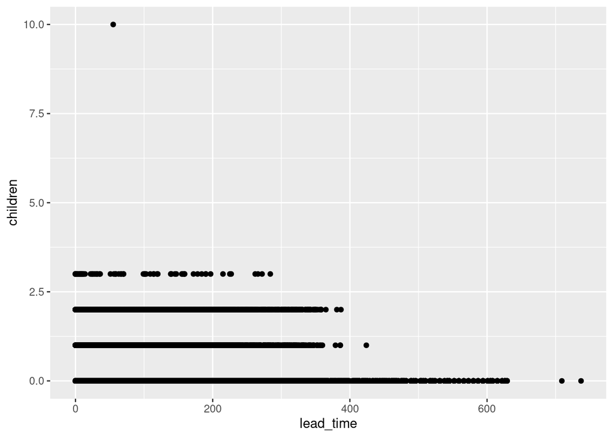

```r
ggplot(data = bookings_df) +
  geom_point(mapping = aes(x = lead_time, y = children))
```

To map ‘stays_in_weekend_nights’ on the x-axis and ‘children’ on the y-axis

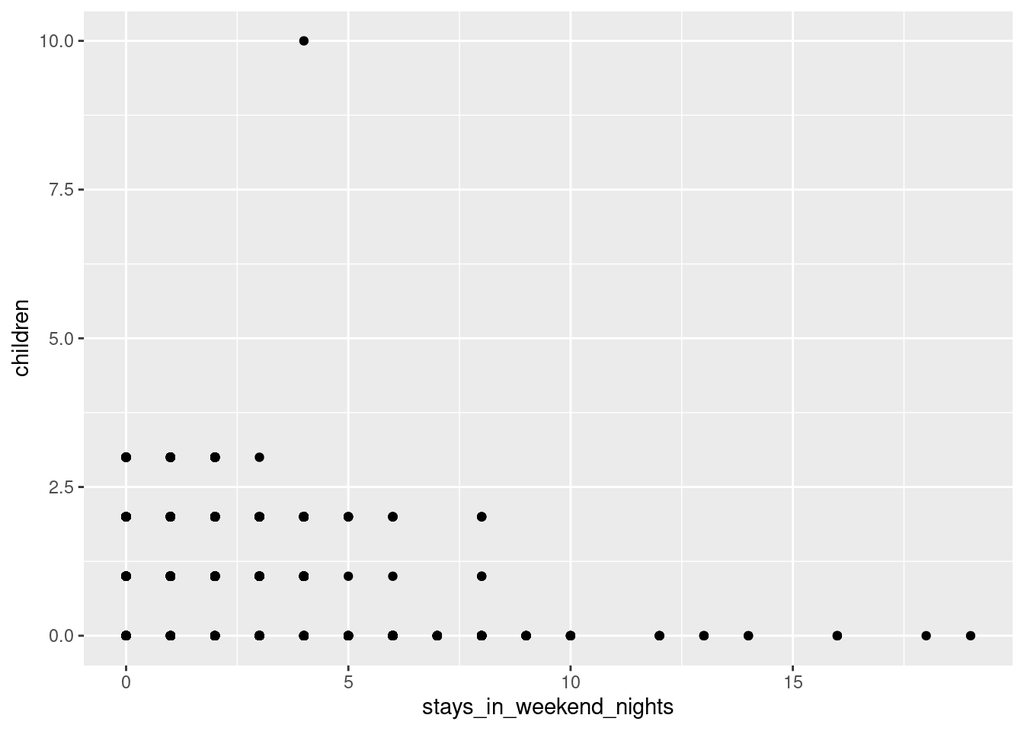

```r
ggplot(data =bookings_df) +
  geom_point(mapping = aes(x = stays_in_weekend_nights, y = children))
```

Previously, `geom_point` was used to make a scatter plot comparing lead time and number of children. Now,`geom_bar` is used to make a bar chart in this code chunk:

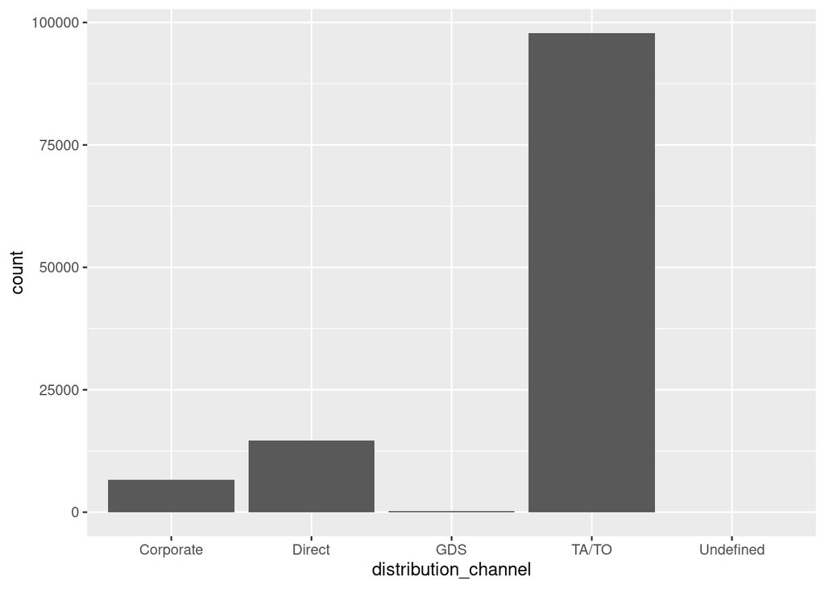

```r
ggplot(data = bookings_df) +
  geom_bar(mapping = aes(x = distribution_channel))
```

Now,if I want to know the number of bookings for each distribution type is different depending on whether or not there was a deposit or what market segment they represent. Am using’fill=deposit_type’ to accomplish this.

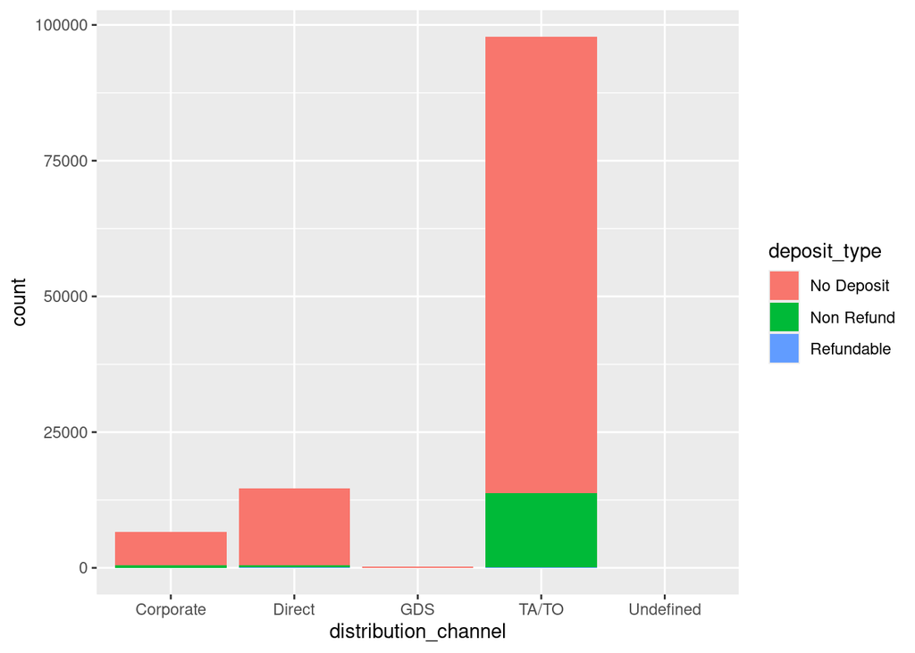

```r
ggplot(data = bookings_df) +
  geom_bar(mapping = aes(x = distribution_channel, fill=deposit_type))
```

Now below is the code to answer the question about different market segments.We will use ‘fill=market_segment’ to accomplish this.

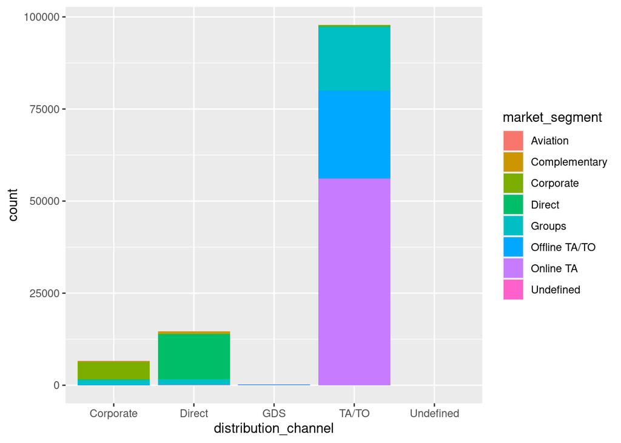

```r
ggplot(data = bookings_df) +
  geom_bar(mapping = aes(x = distribution_channel, fill=market_segment))
```

After reviewing the charts let us create separate charts for each deposit type and market segment to help them understand the differences more clearly.

## Chart for each deposit type

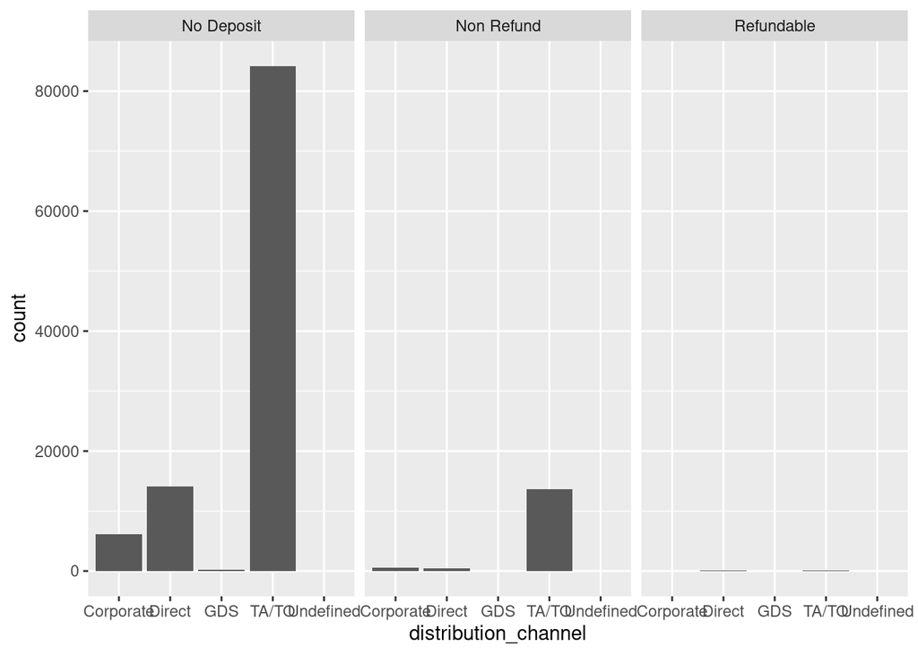

```r
ggplot(data = bookings_df) +
  geom_bar(mapping = aes(x = distribution_channel)) +
  facet_wrap(~deposit_type)
```

## Chart for each market segment

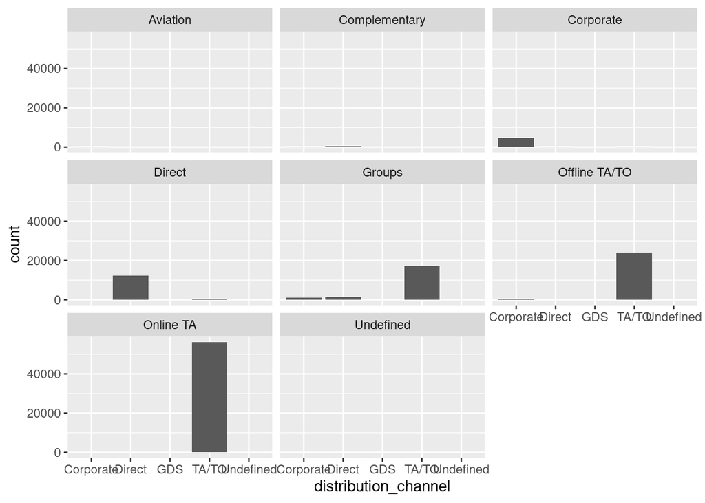

```r
ggplot(data = bookings_df) +
  geom_bar(mapping = aes(x = distribution_channel)) +
  facet_wrap(~market_segment)
```

## ‘facet grid’ function

The `facet_grid` function does something similar. The main difference is that `facet_grid` will include plots even if they are empty. Run the code chunk below to check it out:

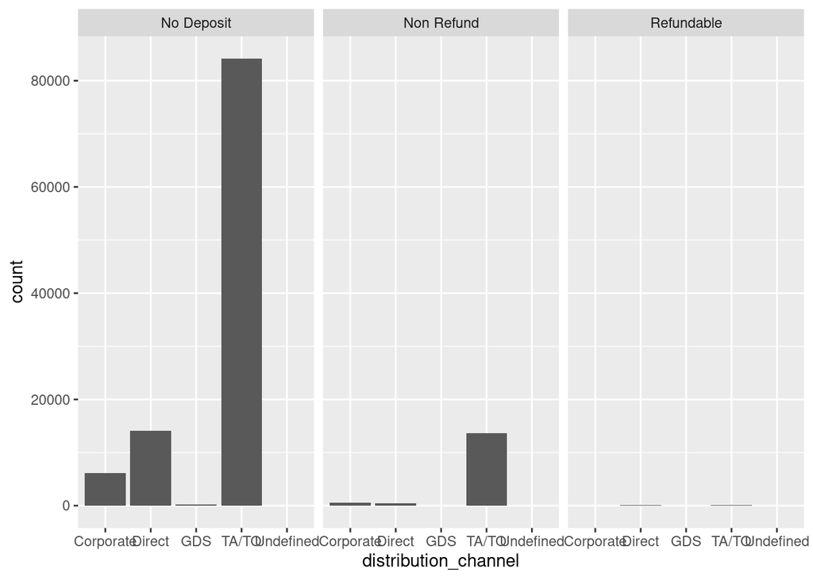

```r
ggplot(data = bookings_df) +
  geom_bar(mapping = aes(x = distribution_channel)) +
  facet_grid(~deposit_type)
```

## All in one chart

Now, lets put all of this in one chart and explore the differences by deposit type and market segment.

Notice how the ~ character is being used before the variables that the chart is being split by:

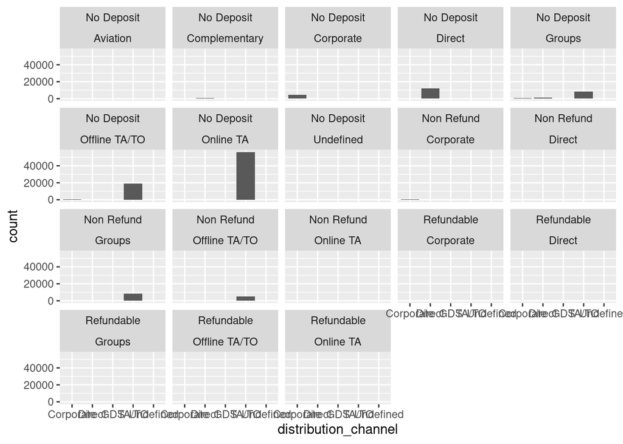

```r
ggplot(data = bookings_df) +
  geom_bar(mapping = aes(x = distribution_channel)) +
  facet_wrap(~deposit_type~market_segment)
```

## creating a bar chart

Showing each hotel type and market segment.Use different colors to represent each market segment:

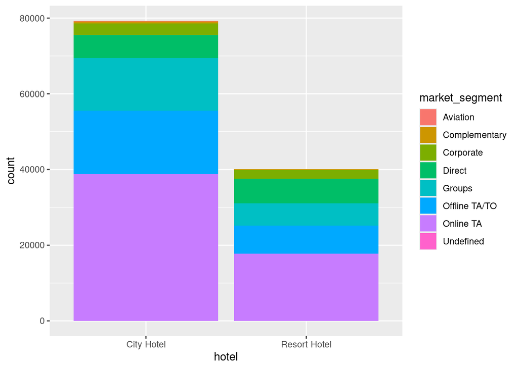

```r
ggplot(data = bookings_df) +
  geom_bar(mapping = aes(x = hotel, fill = market_segment))
```

Lets use the facet_wrap() function to create a separate plot for each market segment:

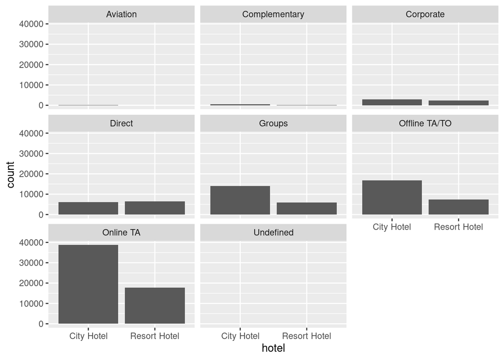

```r
ggplot(data = bookings_df) +
  geom_bar(mapping = aes(x = hotel)) +
  facet_wrap(~market_segment)
```

## Add title

The first thing people will pay attention to when they encounter a data visualization for the first time is at tilte. To add a title, we will add `labs()` at the end of `ggplot()` command and then input a title there as shown below:

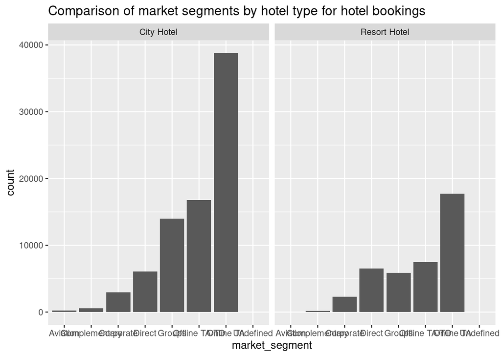

```r
ggplot(data = bookings_df) +
  geom_bar(mapping = aes(x = market_segment)) +
  facet_wrap(~hotel) +
  labs(title="Comparison of market segments by hotel type for hotel bookings")
```

Also adding another detail about what time period this data covers. To do this, find out when the data is from.

To do this I used `min()` and ’max()’function on the year column in the data

```r
min(bookings_df$arrival_date_year)
```

```
## [1] 2015
```

```r
max(bookings_df$arrival_date_year)
```

```
## [1] 2017
```

Here i need to save them as varaibales in order to use them in labelling.

```r
mindate <- min(bookings_df$arrival_date_year)
```

```r
maxdate <- max(bookings_df$arrival_date_year)
```

## Subtitles

lets add subtitle in the labs() function

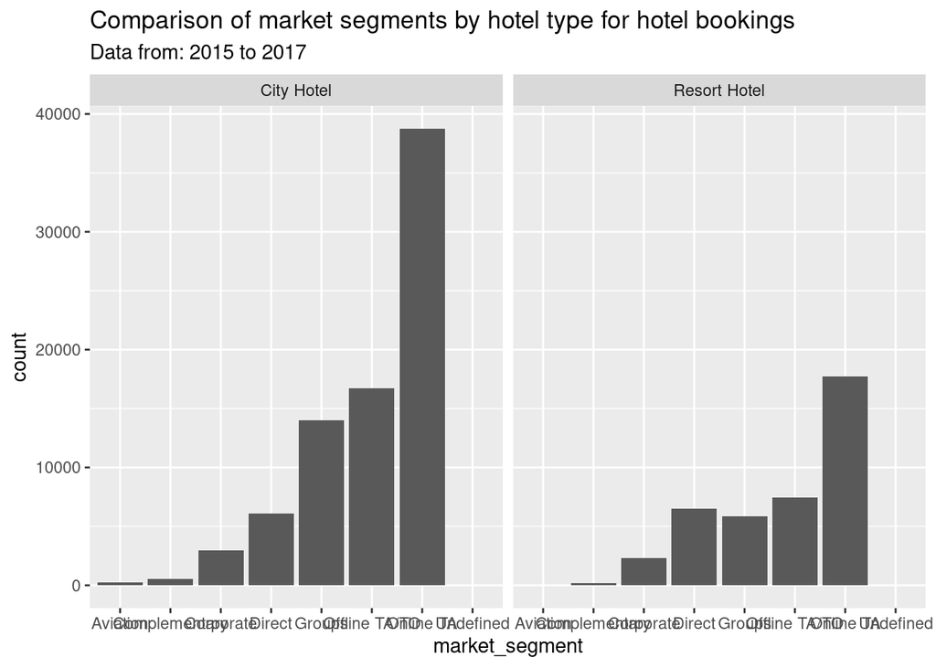

```r
ggplot(data = bookings_df) +
  geom_bar(mapping = aes(x = market_segment)) + facet_wrap(~hotel) +
  labs(title="Comparison of market segments by hotel type for hotel bookings",
       subtitle=paste0("Data from: ", mindate, " to ", maxdate))
```

## Caption

Switching subtitle to caption which will be in bottom right corner

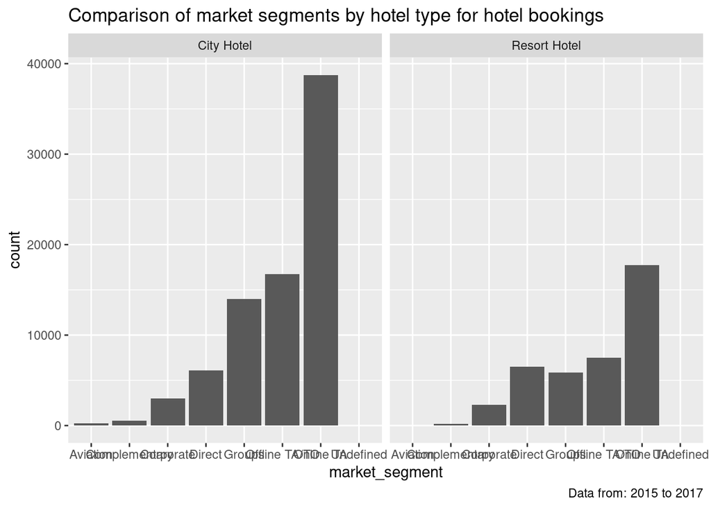

```r
ggplot(data = bookings_df) +
  geom_bar(mapping = aes(x = market_segment)) + facet_wrap(~hotel) +
  labs(title="Comparison of market segments by hotel type for hotel bookings",
       caption=paste0("Data from: ", mindate, " to ", maxdate))
```

## Making x-axis and y-axis labels very clear

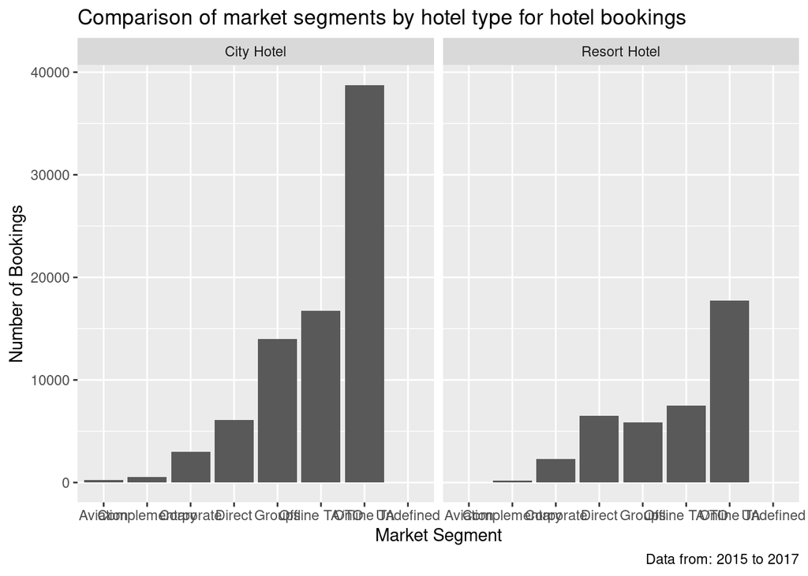

```r
ggplot(data = bookings_df) +
  geom_bar(mapping = aes(x = market_segment)) + facet_wrap(~hotel) +
  labs(title="Comparison of market segments by hotel type for hotel bookings",
       caption=paste0("Data from: ", mindate, " to ", maxdate),
       x="Market Segment",
       y="Number of Bookings")
```

## Saving chart

```r
ggsave('bookings_df.png',
       width=16,
       height=8)
```